# STA 141A Course Project Report

Matthew Ward

2025-03-04

**Abstract**

This project analyzes neural activity in mice during a decision-making task, focusing on how task conditions and brain area-specific activity influence performance. Using logistic regression and random forest models with PCA features, I predict trial outcomes, finding that neural activity is stronger during successful trials and varies significantly across brain areas and contrast conditions. My findings show the importance of the session/mouse and time specific data in predicting how a decision will be made.

**Section 1: Introduction**

In this project, I analyze a subset of data collected by Steinmetz et al. (2019) to understand the neural mechanisms underlying decision-making in mice. The study involved presenting visual stimuli to mice and recording neural activity in the visual cortex during decision-making tasks. My primary objective is to explore how neural activity varies with different task conditions, such as contrast levels and feedback types, and to identify patterns that correlate with successful task performance. I will then apply this knowledge to the preparation of the data for integration, enabling better predictive performance. Finally, I will build a prediction model to predict the outcome, and then test it on given test data.

**Data Description**

The dataset includes recordings from 18 sessions across four mice, with each session comprising several hundred trials. For each trial, we have information on the contrast levels of the visual stimuli, the feedback type (success or failure), and the spike trains of neurons in the visual cortex. I focus on the spike trains from the onset of the stimuli to 0.4 seconds post-onset.

**Data Structure**

A total of 18 RDS files are provided that contain the records from 18 sessions. In each RDS file, you can find the name of mouse from `mouse_name` and date of the experiment from `date_exp`.

- `feedback_type`: type of the feedback, 1 for success and -1 for failure
- `contrast_left`: contrast of the left stimulus
- `contrast_right`: contrast of the right stimulus
- `time`: centers of the time bins for `spks`
- `spks`: numbers of spikes of neurons in the visual cortex in time bins defined in `time`
- `brain_area`: area of the brain where each neuron lives

Take the 11th trial in Session 5 for example, we can see that the left contrast for this trial is

```
## [1] 1
```

the right contrast is

```
## [1] 0
```

the feedback (i.e., outcome) of the trial is

```
## [1] 1
```

There are a total of

```
## [1] 1077
```

neurons in this trial from

```
## [1] 10
```

areas of the brain. The spike trains of these neurons are stored in

```
##      [,1] [,2] [,3] [,4] [,5] [,6] [,7] [,8] [,9] [,10] [,11] [,12] [,13] [,14]
## [1,]    1    0    1    0    0    0    0    0    0     0     0     0     0     0
## [2,]    0    0    0    0    0    0    0    0    0     0     0     0     0     0
## [3,]    0    0    0    0    0    0    0    0    0     0     0     0     0     0
## [4,]    0    1    0    0    0    0    0    0    0     0     0     0     0     0
## [5,]    0    0    0    0    0    0    0    0    0     0     0     0     0     0
## [6,]    0    0    0    0    0    0    0    0    0     0     0     0     0     0
##      [,15] [,16] [,17] [,18] [,19] [,20] [,21] [,22] [,23] [,24] [,25] [,26]
## [1,]     0     0     0     0     0     0     0     0     0     0     0     0
## [2,]     0     0     0     0     0     0     0     0     0     0     0     0
## [3,]     0     0     0     0     0     0     0     0     0     0     0     0
## [4,]     0     0     0     0     0     0     0     0     0     0     0     0
## [5,]     0     0     0     0     0     0     0     0     0     0     0     0
## [6,]     0     0     0     0     0     0     0     0     0     0     0     0
##      [,27] [,28] [,29] [,30] [,31] [,32] [,33] [,34] [,35] [,36] [,37] [,38]
## [1,]     0     0     0     0     0     0     0     0     0     0     0     0
## [2,]     0     0     0     0     0     0     0     0     0     0     0     0
## [3,]     0     0     0     0     0     0     0     0     0     0     0     0
## [4,]     0     0     0     0     0     0     0     0     0     0     0     0
## [5,]     0     0     0     0     0     0     0     0     0     0     0     0
## [6,]     0     0     0     0     0     0     0     0     0     0     0     0
##      [,39] [,40]
## [1,]     0     0
## [2,]     0     1
## [3,]     0     0
## [4,]     0     0
## [5,]     0     0
## [6,]     0     0
```

which is a

```
## [1] 1077
```

by

```
## [1] 40
```

matrix with each entry being the number of spikes of one neuron (i.e., row) in each time bin (i.e., column).

**Section 2: Exploratory Analysis**

**Summarize Session Information**

We can report mouse_name, date_exp, number of brain_area, number of neurons, number of trials, and success rate for each session.

| mouse_name | date_exp | n_brain_area | n_neurons | n_trials | success_rate |
| --- | --- | --- | --- | --- | --- |
| Cori | 2016-12-14 | 8 | 734 | 114 | 0.61 |
| Cori | 2016-12-17 | 5 | 1070 | 251 | 0.63 |
| Cori | 2016-12-18 | 11 | 619 | 228 | 0.66 |
| Forssmann | 2017-11-01 | 11 | 1769 | 249 | 0.67 |
| Forssmann | 2017-11-02 | 10 | 1077 | 254 | 0.66 |
| Forssmann | 2017-11-04 | 5 | 1169 | 290 | 0.74 |
| Forssmann | 2017-11-05 | 8 | 584 | 252 | 0.67 |
| Hench | 2017-06-15 | 15 | 1157 | 250 | 0.64 |
| Hench | 2017-06-16 | 12 | 788 | 372 | 0.69 |
| Hench | 2017-06-17 | 13 | 1172 | 447 | 0.62 |
| Hench | 2017-06-18 | 6 | 857 | 342 | 0.80 |
| Lederberg | 2017-12-05 | 12 | 698 | 340 | 0.74 |
| Lederberg | 2017-12-06 | 15 | 983 | 300 | 0.80 |
| Lederberg | 2017-12-07 | 10 | 756 | 268 | 0.69 |
| Lederberg | 2017-12-08 | 8 | 743 | 404 | 0.76 |
| Lederberg | 2017-12-09 | 6 | 474 | 280 | 0.72 |
| Lederberg | 2017-12-10 | 6 | 565 | 224 | 0.83 |
| Lederberg | 2017-12-11 | 10 | 1090 | 216 | 0.81 |

Notably, we can see that Lederberg has the most sessions and appears to have the highest overall success_rate.

**Compare Success Rates Between Mice**

We can compare the average success rates across mice.

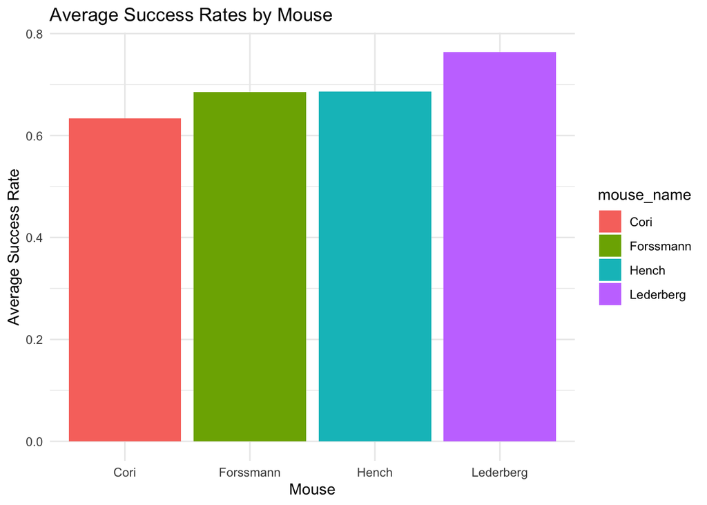

**Session-Level Analysis**

We can analyze neural activity at the session level.

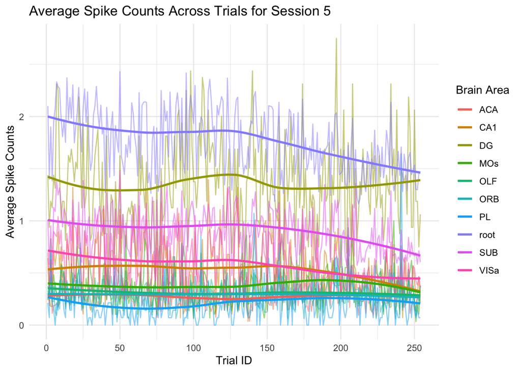

**Trial-Level Analysis**

We can visualize neural activity at the trial level.

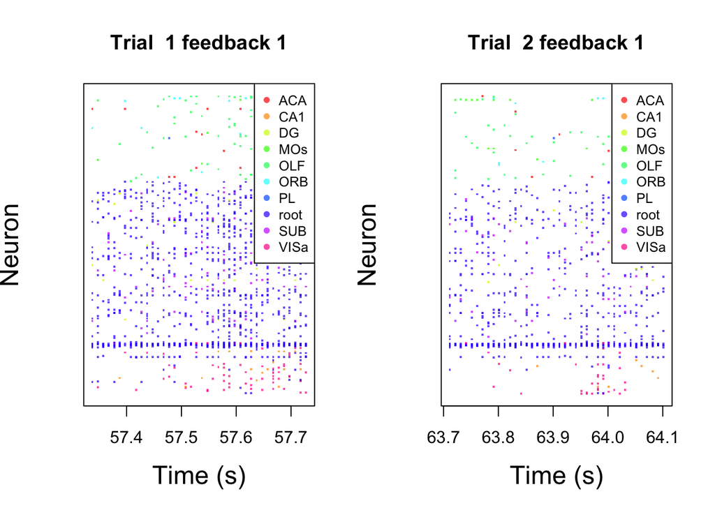

**Success Rates by Contrast Conditions**

We can analyze how success rates vary with different contrast conditions.

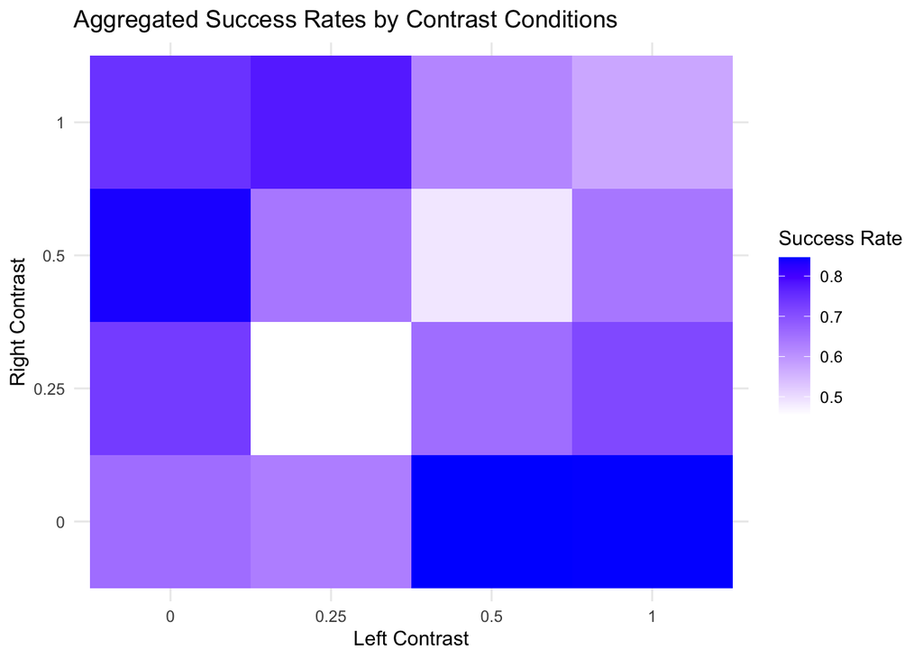

**Interpretation**: The heatmap shows success rates for different combinations of left and right contrasts. High success rates (darker colors) indicate conditions where the mouse reliably made correct decisions. For example, when `contrast_left = 1` and `contrast_right = 0`, the mouse should turn the wheel to the left. A high success rate here suggests the mouse correctly followed the rule. Conversely, when contrasts are equal (e.g., `0.5 vs. 0.5`), success rates are lower, as the correct choice is random.”) This heatmap is the aggregate of every session.

**Neural Activity Across Sessions**

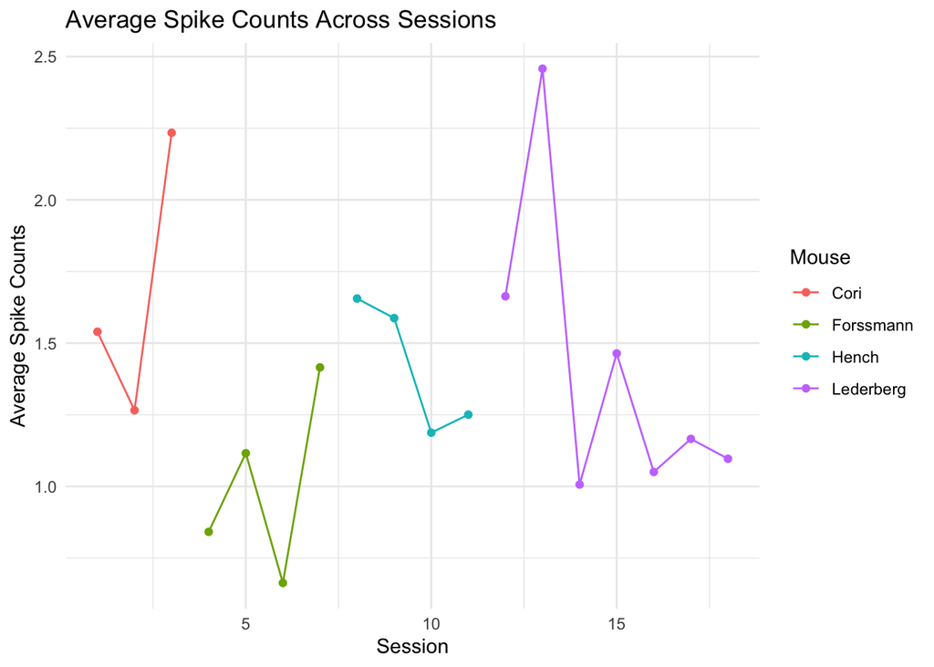

**Feedback Effects on Neural Activity**

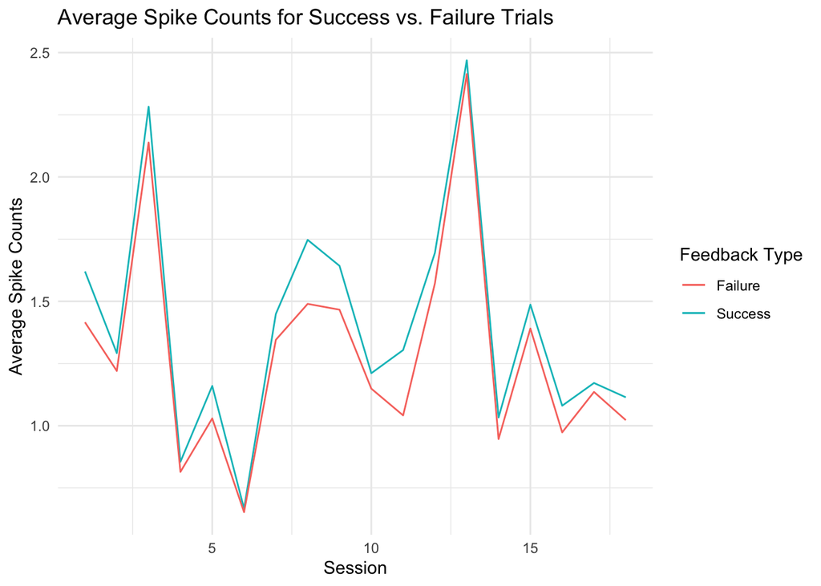

**Interpretation**: As the success line is consistently higher than the failure line, the neural activity appears to be stronger during successful trials. Increases in the success line could indicate that the mouse is learning the task, leading to stronger neural activity during successful trials. Decreases in the failure line could indicate that the mouse is making fewer mistakes, leading to weaker neural activity during failed trials. We can assume then that the model will likely have a bias towards successes in predicting the outcome of trials.

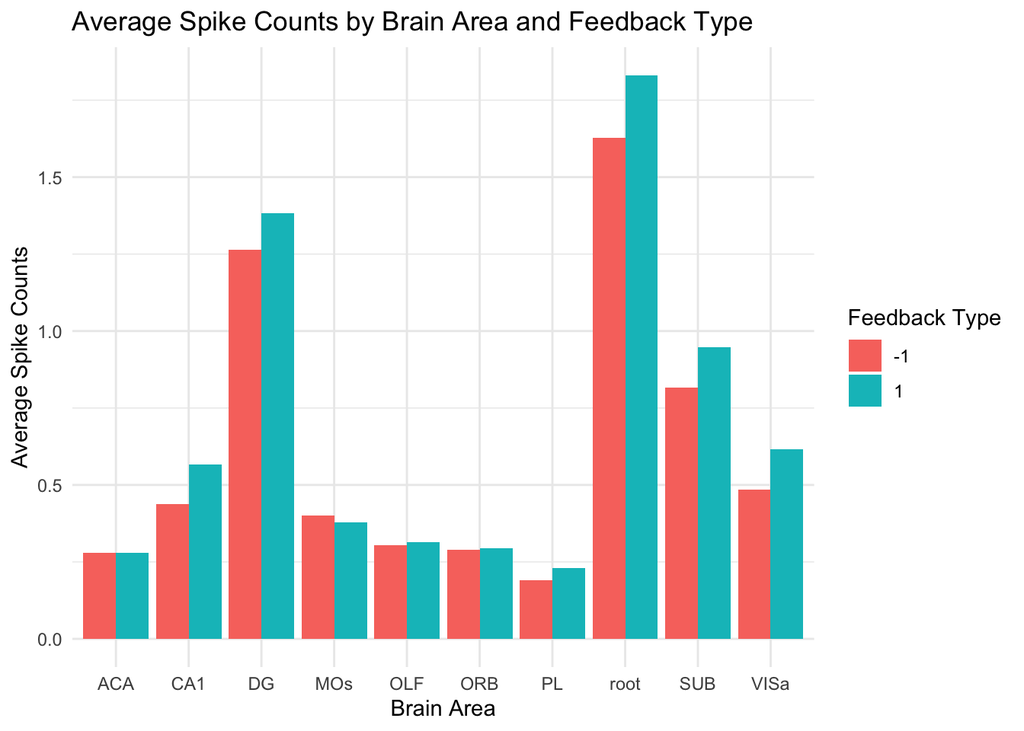

**Interpretation**: The feedback appears to effect some brain areas, such as root or SUB, more than others, like ACA and ORB, which appear to have about equal average spike counts depending on feedback type. Because of this, a focus on filtering to certain brain areas may not be the best way to predict the outcome of trials.

```
## [1] 57.5774
```

**Interpretation**: Each mouse has periods of time during their trials in which the amount of active neurons is at its highest. For session 5, trial 1, it is at time = 57.5774 seconds.

**Key Insights**

#### **2. Brain Area-Specific Activity**

- **Variability in Brain Area Activity:**
  - Certain brain areas (e.g., “root”) exhibit **higher neural activity** compared to others.
  - This suggests that **specific brain areas** may play a more significant role in processing the visual stimuli or making decisions.
- **Feedback-Dependent Activity:**
  - Neural activity patterns vary depending on **feedback type** (success or failure).
  - For example, certain brain areas may show **increased activity** during successful trials, while others may show **decreased activity** during failed trials.

#### **3. Contrast Conditions and Decision-Making**

- **Clear Contrast Differences Drive Success:**
  - Mice perform best when there is a **clear difference** between the left and right contrasts (e.g., `1 vs. 0`).
  - This suggests that mice rely on **contrast differences** to make decisions, and their performance improves when the task is easier (i.e., the correct choice is more obvious).
- **Random Guessing in Equal Contrasts:**
  - When the left and right contrasts are **equal** (e.g., `0.5 vs. 0.5`), success rates drop to around **50%**, indicating that mice are **guessing** rather than making informed decisions.
  - This aligns with the experimental design, where the correct choice is **random** in equal contrast conditions.

#### **4. Individual Differences Between Mice**

- **Variability in Success Rates:**
  - Some mice have **higher success rates** compared to others.
  - This suggests **individual differences** in learning ability, decision-making, or engagement with the task.
  - This may mean that focusing on some mice over others may be a better way to improving the predictive model.
- **Variability in Neural Activity Trends:**
  - Neural activity trends vary between mice, with some showing an **upward trend** and others showing a **downward trend**.
  - These differences may reflect **variability in how mice adapt** to the task over time.

#### **5. Feedback Effects on Neural Activity**

- **Feedback as a Modulator of Neural Activity:**
  - **Successful trials** are associated with **higher spike counts**, suggesting that positive feedback may **enhance neural engagement**.
  - **Failed trials** are associated with **lower spike counts**, suggesting that negative feedback may **reduce neural activity** or lead to disengagement.

#### **6. Temporal Dynamics of Neural Activity**

- **Trial-Level Variability:**
  - Neural activity varies significantly across trials, even within the same session.
  - This variability may reflect **changes in attention**, **task difficulty**, or **feedback effects** on a trial-by-trial basis.
- **Time-Dependent Patterns:**
  - Neural activity is **temporally organized**, with spikes occurring at specific time points during the trial.
  - This suggests that neural activity reflects **processing of visual stimuli** or **decision-making processes**.

**Section 3: Data Integration**

**Temporal Features**

We can implement temporal features to the data to filter out times when there are lower average spike counts during the trials.

**Neural Activity Features**

```
## # A tibble: 6 × 11
##   trial_id feedback_type[,1] contrast_left[,1] contrast_right[,1] avg_spikes
##      <int>             <dbl>             <dbl>              <dbl>      <dbl>
## 1        1                 1              0                  1         1.31
## 2        2                 1              0                  0         0.862
## 3        3                -1              0.25               0.25      1.27
## 4        4                -1              0                  0         0.847
## 5        5                 1              0                  0         1.26
## 6        6                 1              0.5                1         1.32
## # ℹ 6 more variables: prop_active_neurons <dbl>, avg_firing_rate <dbl>,
## #   brain_area_avg <list>, filtered_avg_spikes <dbl>,
## #   filtered_prop_active_neurons <dbl>, filtered_avg_firing_rate <dbl>
```

**Normalization**

```
## # A tibble: 6 × 4
## # Groups:   neuron_id [6]
##   trial_id neuron_id spike_count normalized_spikes[,1]
##      <int>     <int>       <dbl>                 <dbl>
## 1        1         1           0                -0.387
## 2        1         2           0                -1.04
## 3        1         3           0                -0.231
## 4        1         4           3                 1.51
## 5        1         5           2                 0.478
## 6        1         6           0                -0.174
```

- Neural activity can vary significantly across sessions due to differences in baseline firing rates or recording conditions. Z-score normalization ensures that spike counts are on a comparable scale across sessions, allowing the model to focus on relative changes in activity rather than absolute values.
- **Key Insight**: Normalization is critical for integrating data across sessions, as it reduces session-specific biases and ensures that the model can generalize well to new data.

**Principal Component Analysis**

```
## # A tibble: 6 × 16
##   trial_id feedback_type[,1] contrast_left[,1] contrast_right[,1] avg_spikes
##      <int>             <dbl>             <dbl>              <dbl>      <dbl>
## 1        1                 1                 0                  1       1.31
## 2        1                 1                 0                  1       1.31
## 3        1                 1                 0                  1       1.31
## 4        1                 1                 0                  1       1.31
## 5        1                 1                 0                  1       1.31
## 6        1                 1                 0                  1       1.31
## # ℹ 11 more variables: prop_active_neurons <dbl>, avg_firing_rate <dbl>,
## #   brain_area_avg <list>, filtered_avg_spikes <dbl>,
## #   filtered_prop_active_neurons <dbl>, filtered_avg_firing_rate <dbl>,
## #   PC1 <dbl>, PC2 <dbl>, PC3 <dbl>, PC4 <dbl>, PC5 <dbl>
```

- Neural activity data is high-dimensional, with many neurons and time bins. PCA reduces the dimensionality of the data while preserving the most important patterns of variance. This not only simplifies the model but also helps mitigate the risk of overfitting.
- **Key Insight**: The first 5 principal components capture the majority of the variance in the neural activity data, allowing the model to focus on the most informative features for prediction.

**Section 4: Predictive Modeling**

**Logistic Regression Model**

**Model Training**

Started off with a logistic regression model.

**Apply Model to Each Session**

```
## Session ID: 1
## Mouse Name: Cori
## Date of Experiment: 2016-12-14
## Model Accuracy: 0.768018
## Confusion Matrix:
##          Actual
## Predicted   0   1
##         0 112  43
##         1  60 229
##
## Session ID: 2
## Mouse Name: Cori
## Date of Experiment: 2016-12-17
## Model Accuracy: 0.722161
## Confusion Matrix:
##          Actual
## Predicted   0   1
##         0 142  67
##         1 185 513
##
## Session ID: 3
## Mouse Name: Cori
## Date of Experiment: 2016-12-18
## Model Accuracy: 0.7022026
## Confusion Matrix:
##          Actual
## Predicted   0   1
##         0 110  89
##         1 249 687
##
## Session ID: 4
## Mouse Name: Forssmann
## Date of Experiment: 2017-11-01
## Model Accuracy: 0.7328326
## Confusion Matrix:
##          Actual
## Predicted   0   1
##         0 114  67
##         1 182 569
##
```

[output cut: 124 more lines]

```
## Confusion Matrix:
##          Actual
## Predicted   0   1
##         0   9   1
##         1 109 676
##
## Session ID: 18
## Mouse Name: Lederberg
## Date of Experiment: 2017-12-11
## Model Accuracy: 0.8134172
## Confusion Matrix:
##          Actual
## Predicted   0   1
##         0  17  15
##         1 163 759
```

**Combined Model for All Sessions**

```
## Combined Logistic Regression Model Accuracy with PCA: 0.7252441
```

```
## Combined Logistic Regression Model Confusion Matrix with PCA:
```

```
##          Actual
## Predicted     0     1
##         0   800   648
##         1  5262 14800
```

**Random Forest Model**

**Model Training**

Decided on using a random forest model for the second model because of its low risk of overfitting, as the data includes many features.

```
## Session ID: 1
## Mouse Name: Cori
## Date of Experiment: 2016-12-14
## Model Accuracy: 0.768018
## Confusion Matrix:
##          Actual
## Predicted   0   1
##         0 112  43
##         1  60 229
##
## Session ID: 2
## Mouse Name: Cori
## Date of Experiment: 2016-12-17
## Model Accuracy: 0.722161
## Confusion Matrix:
##          Actual
## Predicted   0   1
##         0 142  67
##         1 185 513
##
## Session ID: 3
## Mouse Name: Cori
## Date of Experiment: 2016-12-18
## Model Accuracy: 0.7022026
## Confusion Matrix:
##          Actual
## Predicted   0   1
##         0 110  89
##         1 249 687
##
## Session ID: 4
## Mouse Name: Forssmann
## Date of Experiment: 2017-11-01
## Model Accuracy: 0.7328326
## Confusion Matrix:
##          Actual
## Predicted   0   1
##         0 114  67
##         1 182 569
##
```

[output cut: 124 more lines]

```
## Confusion Matrix:
##          Actual
## Predicted   0   1
##         0   9   1
##         1 109 676
##
## Session ID: 18
## Mouse Name: Lederberg
## Date of Experiment: 2017-12-11
## Model Accuracy: 0.8134172
## Confusion Matrix:
##          Actual
## Predicted   0   1
##         0  17  15
##         1 163 759
```

**Combined Model for All Sessions**

```
## Combined Random Forest Model Accuracy with PCA: 1
```

```
## Combined Random Forest Model Confusion Matrix with PCA:
```

```
##          Actual
## Predicted     0     1
##         0  6062     0
##         1     0 15448
```

- For some reason, the random forest model when using the combined data predicts with 100% accuracy. This must be some kind of issue, so lets try filtering the data to just one mouse.

**Final Models**

**Models Training**

```
## Logistic Regression Model Accuracy (Lederberg): 0.7691862
```

```
## Logistic Regression Model Confusion Matrix (Lederberg):
```

```
##          Actual
## Predicted    0    1
##         0   97   98
##         1 1893 6538
```

- It looks like the logistic regression model with regards to Lederberg has a heavy bias towards successes, only predicting failures right about half the time.

```
## Random Forest Model Accuracy (Lederberg): 1
```

```
## Random Forest Model Confusion Matrix (Lederberg):
```

```
##          Actual
## Predicted    0    1
##         0 1990    0
##         1    0 6636
```

- The random forest model again predicts with 100% accuracy, this time suggesting an issue with the test data being used to measure the effectiveness of the model.

**Section 5: Prediction Performance on the Test Sets**

**Prepping Test Data**

- The test data needs to be prepared in the same way that the training data was prepared for the model originally.

**Evaluating Model Performence**

```
## Test Data Performance with PCA Features:
```

```
## Confusion Matrix:
```

```
##          Actual
## Predicted   -1    1
##         0  406  407
##         1  702 2598
```

```
## Accuracy: 0.7303671
```

```
## Precision: 0.8645591
```

```
## Recall: 0.7872727
```

```
## F1-Score: 0.8241079
```

**Citations**

- https://pdf.ac/4v4gud
- https://pdf.ac/1XkISZ
- https://pdf.ac/2SY12T
- https://pdf.ac/2JRNrX
- https://pdf.ac/3Ct0YB
- https://chatgpt.com/share/67d7c449-a5bc-8007-8cce-ba031e075cda

### Appendix

```r
# Load necessary libraries
suppressWarnings(library(tidyverse))
suppressWarnings(library(knitr))
suppressWarnings(library(dplyr))
session=list()
for(i in 1:18){
  session[[i]]=readRDS(paste('./Data/session',i,'.rds',sep=''))
}
session[[5]]$contrast_left[11]
session[[5]]$contrast_right[11]
session[[5]]$feedback_type[11]
length(session[[5]]$brain_area)
length(unique(session[[5]]$brain_area))
head(session[[5]]$spks[[11]])
dim(session[[5]]$spks[[11]])[1]
dim(session[[5]]$spks[[11]])[2]
# Create a tibble to store session metadata
n.session <- length(session)
meta <- tibble(
  mouse_name = rep('name', n.session),
  date_exp = rep('dt', n.session),
  n_brain_area = rep(0, n.session),
  n_neurons = rep(0, n.session),
  n_trials = rep(0, n.session),
  success_rate = rep(0, n.session)
)

# Fill the metadata tibble
for (i in 1:n.session) {
  tmp <- session[[i]]
  meta[i, 1] <- tmp$mouse_name
  meta[i, 2] <- tmp$date_exp
  meta[i, 3] <- length(unique(tmp$brain_area))
  meta[i, 4] <- dim(tmp$spks[[1]])[1]
  meta[i, 5] <- length(tmp$feedback_type)
  meta[i, 6] <- mean(tmp$feedback_type + 1) / 2
}

# Print the metadata table
kable(meta, format = "html", table.attr = "class='table table-striped'", digits = 2)
# Summarize success rates by mouse
mouse_summary <- meta %>%
  group_by(mouse_name) %>%
  summarize(avg_success_rate = mean(success_rate))

# Plot success rates by mouse
ggplot(mouse_summary, aes(x = mouse_name, y = avg_success_rate, fill = mouse_name)) +
  geom_bar(stat = "identity") +
  labs(title = "Average Success Rates by Mouse",
       x = "Mouse",
       y = "Average Success Rate") +
  theme_minimal()
# Function to calculate average spike counts per brain area for a given trial
average_spike_area <- function(i.t, this_session) {
  spk.trial = this_session$spks[[i.t]]  # Extract spike data for the trial
  area = this_session$brain_area  # Extract brain area labels
  spk.count = apply(spk.trial, 1, sum)  # Calculate total spikes per neuron
  spk.average.tapply = tapply(spk.count, area, mean)  # Average spikes per brain area
  return(spk.average.tapply)
}

# Analyze Session 5 (chosen at random)
i.s <- 5
n.trial <- length(session[[i.s]]$feedback_type)
n.area <- length(unique(session[[i.s]]$brain_area))

# Create trial.summary for Session 5
trial.summary <- matrix(nrow = n.trial, ncol = n.area + 4)
for (i.t in 1:n.trial) {
  avg_spikes <- average_spike_area(i.t, this_session = session[[i.s]])
  trial.summary[i.t, ] <- c(
    avg_spikes,
    session[[i.s]]$feedback_type[i.t],
    session[[i.s]]$contrast_left[i.t],
    session[[i.s]]$contrast_right[i.t],
    i.t
  )
}

# Add column names
colnames(trial.summary) <- c(
  names(avg_spikes),  # Names of brain areas
  "feedback", "left_contr", "right_contr", "id"
)

# Convert to a tibble
trial.summary <- as_tibble(trial.summary)

# Plot average spike counts across trials
trial.summary.long <- trial.summary %>%
  pivot_longer(cols = -c(feedback, left_contr, right_contr, id),
               names_to = "area",
               values_to = "average_spikes")

ggplot(trial.summary.long, aes(x = id, y = average_spikes, color = area)) +
  geom_line(alpha = 0.5) +
  geom_smooth(method = "loess", se = FALSE) +
  labs(title = "Average Spike Counts Across Trials for Session 5",
       x = "Trial ID",
       y = "Average Spike Counts",
       color = "Brain Area") +
  theme_minimal()
# Function to plot neural activity for a single trial
plot.trial <- function(i.t, area, area.col, this_session) {
  spks <- this_session$spks[[i.t]]
  n.neuron <- dim(spks)[1]
  time.points <- this_session$time[[i.t]]

  plot(0, 0, xlim = c(min(time.points), max(time.points)), ylim = c(0, n.neuron + 1),
       col = 'white', xlab = 'Time (s)', yaxt = 'n', ylab = 'Neuron',
       main = paste('Trial ', i.t, 'feedback', this_session$feedback_type[i.t]), cex.lab = 1.5)

  for (i in 1:n.neuron) {
    i.a <- which(area == this_session$brain_area[i])
    col.this <- area.col[i.a]

    ids.spike <- which(spks[i, ] > 0)  # Find spike timestamps
    if (length(ids.spike) > 0) {
      points(x = time.points[ids.spike], y = rep(i, length(ids.spike)),
             pch = '.', cex = 2, col = col.this)
    }
  }

  legend("topright", legend = area, col = area.col, pch = 16, cex = 0.8)
}

# Plot neural activity for Trial 1 and Trial 2 in Session 2
area.col <- rainbow(n = n.area, alpha = 0.7)
varname <- names(trial.summary)
area <- varname[1:(length(varname) - 4)]
par(mfrow = c(1, 2))
plot.trial(1, area, area.col, session[[i.s]])
plot.trial(2, area, area.col, session[[i.s]])
par(mfrow = c(1, 1))
# Function to calculate and plot success rates by contrast conditions
analyze_success_rates <- function(i.s, session) {
  session_data <- session[[i.s]]

  # Calculate success rates for different contrast conditions
  success_rates <- tibble(
    contrast_left = session_data$contrast_left,
    contrast_right = session_data$contrast_right,
    feedback_type = session_data$feedback_type
  ) %>%
    group_by(contrast_left, contrast_right) %>%
    summarize(success_rate = mean(feedback_type == 1), .groups = 'drop')

  # Plot success rates
  plot <- ggplot(success_rates, aes(x = factor(contrast_left), y = factor(contrast_right), fill = success_rate)) +
    geom_tile() +
    scale_fill_gradient(low = "white", high = "blue") +
    labs(title = paste("Success Rates by Contrast Conditions for Session", i.s),
         x = "Left Contrast",
         y = "Right Contrast",
         fill = "Success Rate") +
    theme_minimal()

  return(plot)
}
# Aggregate success rates across all sessions
all_success_rates <- do.call(rbind, lapply(1:18, function(i.s) {
  session_data <- session[[i.s]]
  tibble(
    contrast_left = session_data$contrast_left,
    contrast_right = session_data$contrast_right,
    feedback_type = session_data$feedback_type,
    session = i.s
  )
}))

# Calculate success rates for each contrast condition
success_rate_summary <- all_success_rates %>%
  group_by(contrast_left, contrast_right) %>%
  summarize(
    success_rate = mean(feedback_type == 1),  # Calculate success rate
    .groups = 'drop'
  )
```

```r
# Plot aggregated success rates
ggplot(success_rate_summary, aes(x = factor(contrast_left), y = factor(contrast_right), fill = success_rate)) +
  geom_tile() +
  scale_fill_gradient(low = "white", high = "blue") +
  labs(
    title = "Aggregated Success Rates by Contrast Conditions",
    x = "Left Contrast",
    y = "Right Contrast",
    fill = "Success Rate"
  ) +
  theme_minimal()
# Calculate average spike counts across sessions
session_spike_summary <- do.call(rbind, lapply(1:18, function(i.s) {
  session_data <- session[[i.s]]

  # Calculate average spike counts per trial
  avg_spikes_per_trial <- sapply(1:length(session_data$feedback_type), function(i.t) {
    mean(rowSums(session_data$spks[[i.t]]))  # Mean spikes per neuron per trial
  })

  # Create a tibble for the session
  tibble(
    session = i.s,
    mouse_name = session_data$mouse_name,
    avg_spikes = mean(avg_spikes_per_trial)  # Average spikes across all trials in the session
  )
}))

# Plot average spike counts across sessions
ggplot(session_spike_summary, aes(x = session, y = avg_spikes, color = mouse_name)) +
  geom_line() +
  geom_point() +  # Add points for better visualization
  labs(
    title = "Average Spike Counts Across Sessions",
    x = "Session",
    y = "Average Spike Counts",
    color = "Mouse"
  ) +
  theme_minimal()
# Calculate spike counts for success vs. failure trials
feedback_spike_summary <- do.call(rbind, lapply(1:18, function(i.s) {
  session_data <- session[[i.s]]

  # Calculate average spike counts for success trials
  success_spikes <- sapply(which(session_data$feedback_type == 1), function(i.t) {
    mean(rowSums(session_data$spks[[i.t]]))  # Mean spikes per neuron for success trials
  })

  # Calculate average spike counts for failure trials
  failure_spikes <- sapply(which(session_data$feedback_type == -1), function(i.t) {
    mean(rowSums(session_data$spks[[i.t]]))  # Mean spikes per neuron for failure trials
  })

  # Handle cases where there are no success or failure trials
  success_avg <- if (length(success_spikes) > 0) mean(success_spikes) else NA
  failure_avg <- if (length(failure_spikes) > 0) mean(failure_spikes) else NA

  # Create a tibble for the session
  tibble(
    session = i.s,
    mouse_name = session_data$mouse_name,
    success_avg = success_avg,
    failure_avg = failure_avg
  )
}))

# Plot success vs. failure spike counts
ggplot(feedback_spike_summary, aes(x = session)) +
  geom_line(aes(y = success_avg, color = "Success")) +
  geom_line(aes(y = failure_avg, color = "Failure")) +
  labs(
    title = "Average Spike Counts for Success vs. Failure Trials",
    x = "Session",
    y = "Average Spike Counts",
    color = "Feedback Type"
  ) +
  theme_minimal()
# Compare feedback effects by brain area
feedback_by_area <- trial.summary.long %>%
  group_by(area, feedback) %>%
  summarize(avg_spikes = mean(average_spikes), .groups = 'drop')

ggplot(feedback_by_area, aes(x = area, y = avg_spikes, fill = factor(feedback))) +
  geom_bar(stat = "identity", position = "dodge") +
  labs(title = "Average Spike Counts by Brain Area and Feedback Type",
       x = "Brain Area",
       y = "Average Spike Counts",
       fill = "Feedback Type") +
  theme_minimal()
# Function to find the time bin with the most active neurons in a trial
find_most_active_time_bin <- function(spks, time_points) {
  # Calculate total spikes per time bin across all neurons
  total_spikes_per_bin <- colSums(spks)

  # Find the time bin with the maximum total spikes
  max_spike_bin <- which.max(total_spikes_per_bin)

  # Return the corresponding time point
  return(time_points[max_spike_bin])
}

# Example: Find the most active time bin for Trial 1 in Session 5
most_active_time_bin <- find_most_active_time_bin(session[[5]]$spks[[1]], session[[5]]$time[[1]])
print(most_active_time_bin)
# Function to filter spike data to the most active time window
filter_to_most_active_window <- function(spks, time_points, window_size = 0.1) {
  # Find the most active time bin
  most_active_time_bin <- find_most_active_time_bin(spks, time_points)

  # Define the time window around the most active time bin
  time_window <- c(most_active_time_bin - window_size, most_active_time_bin + window_size)

  # Find the indices of time points within the window
  time_indices <- which(time_points >= time_window[1] & time_points <= time_window[2])

  # Filter the spike data to the time window
  filtered_spks <- spks[, time_indices]

  return(filtered_spks)
}

# Initialize a list to store filtered spike data
filtered_session_data <- list()

# Loop through each session
for (i in 1:length(session)) {
  session_data <- session[[i]]
  n_trials <- length(session_data$feedback_type)

  # Initialize a list to store filtered spike data for the session
  filtered_spks_session <- list()

  # Loop through each trial in the session
  for (j in 1:n_trials) {
    # Filter spike data to the most active time window
    filtered_spks <- filter_to_most_active_window(session_data$spks[[j]], session_data$time[[j]])

    # Store the filtered spike data
    filtered_spks_session[[j]] <- filtered_spks
  }

  # Store the filtered spike data for the session
  filtered_session_data[[i]] <- filtered_spks_session
}
# Function to calculate features for each trial, including filtered spike data
calculate_features <- function(session_data) {
  n_trials <- length(session_data$feedback_type)
  n_neurons <- dim(session_data$spks[[1]])[1]

  # Initialize a tibble to store features
  features <- tibble(
    trial_id = 1:n_trials,
    feedback_type = session_data$feedback_type,
    contrast_left = session_data$contrast_left,
    contrast_right = session_data$contrast_right,
    avg_spikes = sapply(session_data$spks, function(spks) mean(rowSums(spks))),  # Average spikes per neuron (full trial)
    prop_active_neurons = sapply(session_data$spks, function(spks) mean(rowSums(spks) > 0)),  # Proportion of active neurons (full trial)
    avg_firing_rate = sapply(session_data$spks, function(spks) mean(colMeans(spks))),  # Average firing rate (full trial)
    brain_area_avg = lapply(session_data$spks, function(spks) {  # Average spikes per brain area (full trial)
      area <- session_data$brain_area
      tapply(rowSums(spks), area, mean)
    }),
    # Add features for the most active time window
    filtered_avg_spikes = sapply(1:n_trials, function(i.t) {
      filtered_spks <- filter_to_most_active_window(session_data$spks[[i.t]], session_data$time[[i.t]])
      mean(rowSums(filtered_spks))  # Average spikes per neuron in the most active window
    }),
    filtered_prop_active_neurons = sapply(1:n_trials, function(i.t) {
      filtered_spks <- filter_to_most_active_window(session_data$spks[[i.t]], session_data$time[[i.t]])
      mean(rowSums(filtered_spks) > 0)  # Proportion of active neurons in the most active window
    }),
    filtered_avg_firing_rate = sapply(1:n_trials, function(i.t) {
      filtered_spks <- filter_to_most_active_window(session_data$spks[[i.t]], session_data$time[[i.t]])
      mean(colMeans(filtered_spks))  # Average firing rate in the most active window
    })
  )
```

```r
  return(features)
}

# Example: Calculate features for Session 5
session_5_features <- calculate_features(session[[5]])
head(session_5_features)
# Combined function to flatten, normalize, and reorganize spike counts
process_spike_counts <- function(session_data) {
  n_trials <- length(session_data$feedback_type)
  n_neurons <- dim(session_data$spks[[1]])[1]  # Number of neurons per trial

  # Step 1: Flatten spike counts into a tidy format
  spike_counts <- tibble(
    trial_id = rep(1:n_trials, each = n_neurons),
    neuron_id = rep(1:n_neurons, times = n_trials),
    spike_count = unlist(lapply(session_data$spks, rowSums))  # Sum spikes per neuron per trial
  )

  # Step 2: Normalize spike counts using z-score normalization
  spike_counts <- spike_counts %>%
    group_by(neuron_id) %>%  # Normalize by neuron to account for neuron-specific baselines
    mutate(normalized_spikes = scale(spike_count))  # Z-score normalization

  return(spike_counts)  # Return the normalized spike counts with neuron_id
}

# Example usage for Session 5
session_5_trial_level_spikes <- process_spike_counts(session[[5]])
head(session_5_trial_level_spikes)

# Merge normalized spike counts with other trial-level features
session_5_features = session_5_features %>%
  left_join(session_5_trial_level_spikes, by = "trial_id")
# Function to perform PCA and add principal components to session features
add_pca_features <- function(session_data) {
  # Step 1: Flatten, normalize, and reorganize spike counts
  spike_counts <- process_spike_counts(session_data)

  # Step 2: Reshape normalized spike counts into a wide format for PCA
  wide_normalized_spikes <- spike_counts %>%
    pivot_wider(names_from = neuron_id, values_from = normalized_spikes, values_fill = 0)

  # Step 3: Extract the numeric matrix for PCA
  pca_input <- wide_normalized_spikes %>%
    select(-trial_id) %>%  # Remove non-numeric columns
    as.matrix()

  # Step 4: Remove columns with zero variance
  pca_input <- pca_input[, apply(pca_input, 2, function(x) var(x, na.rm = TRUE) != 0)]

  # Step 5: Perform PCA
  pca_results <- prcomp(pca_input, scale = TRUE)

  # Step 6: Extract the first 5 principal components
  pca_features <- pca_results$x[, 1:5]

  # Step 7: Add trial_id to pca_features for alignment
  pca_features <- as_tibble(pca_features) %>%
    mutate(trial_id = wide_normalized_spikes$trial_id)

  # Step 8: Merge PCA features with session features
  session_features <- calculate_features(session_data)  # Assuming calculate_features is already defined
  session_features <- session_features %>%
    left_join(pca_features, by = "trial_id")

  return(session_features)
}

# Example usage for Session 5
session_5_features_with_pca <- add_pca_features(session[[5]])
head(session_5_features_with_pca)
suppressPackageStartupMessages(suppressWarnings(library(caret)))

# Function to train a logistic regression model with PCA features
train_model_with_pca <- function(session_features) {
  # Recode feedback_type for binary classification
  session_features$feedback_type <- ifelse(session_features$feedback_type == -1, 0, 1)

  # Split data into training and testing sets
  set.seed(141)
  train_index <- createDataPartition(session_features$feedback_type, p = 0.8, list = FALSE)
  train_data <- session_features[train_index, ]
  test_data <- session_features[-train_index, ]

  # Train logistic regression model with PCA features
  model <- glm(feedback_type ~ contrast_left + contrast_right +
               avg_spikes + prop_active_neurons + avg_firing_rate +
               filtered_avg_spikes + filtered_prop_active_neurons + filtered_avg_firing_rate +
               PC1 + PC2 + PC3 + PC4 + PC5,
               data = train_data, family = binomial)

  # Predict on test data
  predictions <- predict(model, test_data, type = "response")
  predicted_classes <- ifelse(predictions > 0.5, 1, 0)

  # Evaluate model performance
  confusion_matrix <- table(Predicted = predicted_classes, Actual = test_data$feedback_type)
  accuracy <- sum(diag(confusion_matrix)) / sum(confusion_matrix)

  return(list(model = model, accuracy = accuracy, confusion_matrix = confusion_matrix))
}
# Apply the model to all sessions with PCA features
apply_model_to_all_sessions_with_pca <- function(session_list) {
  results <- list()

  for (i in 1:length(session_list)) {
    session_data <- session_list[[i]]

    # Calculate features for the session
    session_features <- add_pca_features(session_data)

    # Train and evaluate the model
    model_results <- train_model_with_pca(session_features)

    # Store the results
    results[[i]] <- list(
      session_id = i,
      mouse_name = session_data$mouse_name,
      date_exp = session_data$date_exp,
      model = model_results$model,
      accuracy = model_results$accuracy,
      confusion_matrix = model_results$confusion_matrix
    )
  }

  return(results)
}

# Apply the model to all sessions
all_session_results_with_pca <- suppressWarnings(apply_model_to_all_sessions_with_pca(session))

# Print the results for each session
for (i in 1:length(all_session_results_with_pca)) {
  cat("Session ID:", all_session_results_with_pca[[i]]$session_id, "\n")
  cat("Mouse Name:", all_session_results_with_pca[[i]]$mouse_name, "\n")
  cat("Date of Experiment:", all_session_results_with_pca[[i]]$date_exp, "\n")
  cat("Model Accuracy:", all_session_results_with_pca[[i]]$accuracy, "\n")
  cat("Confusion Matrix:\n")
  print(all_session_results_with_pca[[i]]$confusion_matrix)
  cat("\n")
}
# Function to combine data from all sessions with PCA features
combine_session_data_with_pca <- function(session_list) {
  combined_data <- list()

  for (i in 1:length(session_list)) {
    session_data <- session_list[[i]]

    # Calculate features for the session with PCA
    session_features <- add_pca_features(session_data)

    # Add session ID to the features
    session_features$session_id <- i

    # Append the session data to the combined dataset
    combined_data[[i]] <- session_features
  }
```

```r
  # Combine all session data into a single data frame
  combined_data <- do.call(rbind, combined_data)

  return(combined_data)
}

# Combine data from all sessions with PCA features
all_sessions_data_with_pca <- combine_session_data_with_pca(session)

# Normalize numerical features across all sessions
normalize_combined_data_with_pca <- function(combined_data) {
  combined_data <- combined_data %>%
    group_by(session_id) %>%
    mutate(across(c(avg_spikes, prop_active_neurons, avg_firing_rate,
                    filtered_avg_spikes, filtered_prop_active_neurons, filtered_avg_firing_rate), scale)) %>%
    ungroup()

  return(combined_data)
}

# Normalize the combined data with PCA features
all_sessions_data_with_pca <- normalize_combined_data_with_pca(all_sessions_data_with_pca)

# Convert session_id to factor
all_sessions_data_with_pca$session_id <- as.factor(all_sessions_data_with_pca$session_id)

# Train a single logistic regression model on the combined data with PCA features
train_combined_model_with_pca <- function(combined_data) {
  # Recode feedback_type for binary classification
  combined_data$feedback_type <- ifelse(combined_data$feedback_type == -1, 0, 1)

  # Split the combined data into training and testing sets
  set.seed(141)  # For reproducibility
  train_index <- sample(1:nrow(combined_data), size = 0.8 * nrow(combined_data))
  train_data <- combined_data[train_index, ]
  test_data <- combined_data[-train_index, ]

  # Train logistic regression model with PCA features
  model <- glm(feedback_type ~ contrast_left + contrast_right +
               avg_spikes + prop_active_neurons + avg_firing_rate +
               filtered_avg_spikes + filtered_prop_active_neurons + filtered_avg_firing_rate +
               PC1 + PC2 + PC3 + PC4 + PC5 +
               session_id,
               data = train_data, family = binomial)

  # Predict on test data
  predictions <- predict(model, test_data, type = "response")
  predicted_classes <- ifelse(predictions > 0.5, 1, 0)

  # Evaluate model performance
  confusion_matrix <- table(Predicted = predicted_classes, Actual = test_data$feedback_type)
  accuracy <- sum(diag(confusion_matrix)) / sum(confusion_matrix)

  return(list(model = model, accuracy = accuracy, confusion_matrix = confusion_matrix))
}

# Train the combined logistic regression model with PCA features
combined_model_results_with_pca <- suppressWarnings(train_combined_model_with_pca(all_sessions_data_with_pca))

# Print the results
cat("Combined Logistic Regression Model Accuracy with PCA:", combined_model_results_with_pca$accuracy, "\n")
cat("Combined Logistic Regression Model Confusion Matrix with PCA:\n")
print(combined_model_results_with_pca$confusion_matrix)
suppressPackageStartupMessages(suppressWarnings(library(randomForest)))

# Function to train a Random Forest model with PCA features
train_random_forest_with_pca <- function(session_features) {
  # Recode feedback_type for binary classification
  session_features$feedback_type <- ifelse(session_features$feedback_type == -1, 0, 1)

  # Split data into training and testing sets
  set.seed(141)  # For reproducibility
  train_index <- createDataPartition(session_features$feedback_type, p = 0.8, list = FALSE)
  train_data <- session_features[train_index, ]
  test_data <- session_features[-train_index, ]

  # Train Random Forest model with PCA features
  rf_model <- randomForest(
    feedback_type ~ contrast_left + contrast_right +
      avg_spikes + prop_active_neurons + avg_firing_rate +
      filtered_avg_spikes + filtered_prop_active_neurons + filtered_avg_firing_rate +
      PC1 + PC2 + PC3 + PC4 + PC5 + PC6 + PC7 + PC8 + PC9 + PC10,
    data = train_data,
    ntree = 100,  # Number of trees in the forest
    mtry = sqrt(ncol(train_data) - 1),  # Number of features to consider at each split
    importance = TRUE  # To assess variable importance
  )

  # Predict on test data
  predictions <- predict(rf_model, test_data, type = "response")
  predicted_classes <- ifelse(predictions > 0.5, 1, 0)

  # Evaluate model performance
  confusion_matrix <- table(Predicted = predicted_classes, Actual = test_data$feedback_type)
  accuracy <- sum(diag(confusion_matrix)) / sum(confusion_matrix)

  return(list(model = rf_model, accuracy = accuracy, confusion_matrix = confusion_matrix))
}
# Apply the Random Forest model to all sessions with PCA features
all_session_results_rf_with_pca <- suppressWarnings(apply_model_to_all_sessions_with_pca(session))

# Print the results for each session
for (i in 1:length(all_session_results_rf_with_pca)) {
  cat("Session ID:", all_session_results_rf_with_pca[[i]]$session_id, "\n")
  cat("Mouse Name:", all_session_results_rf_with_pca[[i]]$mouse_name, "\n")
  cat("Date of Experiment:", all_session_results_rf_with_pca[[i]]$date_exp, "\n")
  cat("Model Accuracy:", all_session_results_rf_with_pca[[i]]$accuracy, "\n")
  cat("Confusion Matrix:\n")
  print(all_session_results_rf_with_pca[[i]]$confusion_matrix)
  cat("\n")
}
# Train a combined Random Forest model with PCA features
train_combined_random_forest_with_pca <- function(combined_data) {
  # Recode feedback_type for binary classification
  combined_data$feedback_type <- ifelse(combined_data$feedback_type == -1, 0, 1)

  # Split the combined data into training and testing sets
  set.seed(141)  # For reproducibility
  train_index <- sample(1:nrow(combined_data), size = 0.8 * nrow(combined_data))
  train_data <- combined_data[train_index, ]
  test_data <- combined_data[-train_index, ]

  # Train Random Forest model with PCA features
  rf_model <- randomForest(
    feedback_type ~ contrast_left + contrast_right +
      avg_spikes + prop_active_neurons + avg_firing_rate +
      filtered_avg_spikes + filtered_prop_active_neurons + filtered_avg_firing_rate +
      PC1 + PC2 + PC3 + PC4 + PC5 +
      session_id,
    data = train_data,
    ntree = 100,  # Number of trees in the forest
    mtry = sqrt(ncol(train_data) - 1),  # Number of features to consider at each split
    importance = TRUE  # To assess variable importance
  )
```

```r
  # Predict on test data
  predictions <- predict(rf_model, test_data, type = "response")
  predicted_classes <- ifelse(predictions > 0.5, 1, 0)

  # Evaluate model performance
  confusion_matrix <- table(Predicted = predicted_classes, Actual = test_data$feedback_type)
  accuracy <- sum(diag(confusion_matrix)) / sum(confusion_matrix)

  return(list(model = rf_model, accuracy = accuracy, confusion_matrix = confusion_matrix))
}

# Train the combined Random Forest model with PCA features
combined_rf_results_with_pca <- suppressWarnings(train_combined_random_forest_with_pca(all_sessions_data_with_pca))

# Print the results
cat("Combined Random Forest Model Accuracy with PCA:", combined_rf_results_with_pca$accuracy, "\n")
cat("Combined Random Forest Model Confusion Matrix with PCA:\n")
print(combined_rf_results_with_pca$confusion_matrix)
# Filter sessions 12-18
sessions_12_to_18 <- session[12:18]
# Combine data from sessions 12-18
combined_data_12_to_18 <- combine_session_data_with_pca(sessions_12_to_18)

# Normalize the combined data
combined_data_12_to_18 <- normalize_combined_data_with_pca(combined_data_12_to_18)

# Train the logistic regression model on sessions 12-18
logistic_model_12_to_18 <- train_combined_model_with_pca(combined_data_12_to_18)

# Print the results
cat("Logistic Regression Model Accuracy (Lederberg):", logistic_model_12_to_18$accuracy, "\n")
cat("Logistic Regression Model Confusion Matrix (Lederberg):\n")
print(logistic_model_12_to_18$confusion_matrix)
# Combine data from sessions 12-18
combined_data_12_to_18 <- combine_session_data_with_pca(sessions_12_to_18)

# Normalize the combined data
combined_data_12_to_18 <- normalize_combined_data_with_pca(combined_data_12_to_18)

# Train the logistic regression model on sessions 12-18
random_forest_model_12_to_18 <- suppressWarnings(train_combined_random_forest_with_pca(combined_data_12_to_18))

# Print the results
cat("Random Forest Model Accuracy (Lederberg):", random_forest_model_12_to_18$accuracy, "\n")
cat("Random Forest Model Confusion Matrix (Lederberg):\n")
print(random_forest_model_12_to_18$confusion_matrix)
test_data=list()
for(i in 1:2){
  test_data[[i]]=readRDS(paste('./test/test',i,'.rds',sep=''))
}

# Apply feature engineering to each test session with PCA features
test_features_with_pca <- lapply(test_data, add_pca_features)

# Add session_id to each session's feature data
for (i in 1:length(test_features_with_pca)) {
  test_features_with_pca[[i]]$session_id <- i  # Assign session_id based on the index in the list
}

# Now normalize the test data using the same function
test_features_normalized_with_pca <- lapply(test_features_with_pca, normalize_combined_data_with_pca)

# Combine the normalized test data into a single data frame
combined_test_data_with_pca <- do.call(rbind, test_features_normalized_with_pca)
# Function to evaluate model performance
evaluate_performance <- function(predicted_classes, actual_classes) {
  # Confusion Matrix
  confusion_matrix <- table(Predicted = predicted_classes, Actual = actual_classes)

  # Accuracy
  accuracy <- sum(diag(confusion_matrix)) / sum(confusion_matrix)

  # Precision
  precision <- confusion_matrix[2, 2] / sum(confusion_matrix[, 2])

  # Recall
  recall <- confusion_matrix[2, 2] / sum(confusion_matrix[2, ])

  # F1-Score
  f1_score <- 2 * (precision * recall) / (precision + recall)

  # Return the results
  return(list(
    confusion_matrix = confusion_matrix,
    accuracy = accuracy,
    precision = precision,
    recall = recall,
    f1_score = f1_score
  ))
}

combined_test_data_with_pca$session_id <- factor(combined_test_data_with_pca$session_id,
                                                 levels = levels(all_sessions_data_with_pca$session_id))

# Make predictions on the test data with PCA features
predictions_with_pca <- predict(combined_rf_results_with_pca$model, newdata = combined_test_data_with_pca, type = "response")

# Convert probabilities to class labels (1 for success, 0 for failure)
predicted_classes_with_pca <- ifelse(predictions_with_pca > 0.5, 1, 0)

# Evaluate performance on the test data with PCA features
performance_results_with_pca <- evaluate_performance(predicted_classes_with_pca, combined_test_data_with_pca$feedback_type)

# Print the results
cat("Test Data Performance with PCA Features:\n")
cat("Confusion Matrix:\n")
print(performance_results_with_pca$confusion_matrix)
cat("Accuracy:", performance_results_with_pca$accuracy, "\n")
cat("Precision:", performance_results_with_pca$precision, "\n")
cat("Recall:", performance_results_with_pca$recall, "\n")
cat("F1-Score:", performance_results_with_pca$f1_score, "\n")
```